# Résultats de la liste Glucksman aux élections européennes de mai 2024 dans la région de Normandie

Rapport confidentiel remis au secrétaire général en vue de la préparation des élections législatives de juin 2024

Racine Eva

## INTRODUCTION (2 pts)

### Objectifs

> Connaissant vos capacités en statistique, votre parti politique vous a demandé d’analyser les résultats de la liste Glucksman dans la région Normandie aux élections européennes de mai 2024, par circonscription. Le but est de comprendre les facteurs quantitatifs ou qualitatifs qui sont associés aux résultats afin de faire des prédictions et (éventuellement) de formuler des hypothèses explicatives afin de préparer les élections législatives de juin 2024.

### Description des variables

Le tableau de données comporte les variables suivantes :

- “circ” : Code de la circonscription (ex. 94001 = 1ere circo. du Val de Marne)
- “dept” : Nom du département
- “regi” : Nom de la région
- “typo” : typologie en “urbain” et “rural”
- “Aubry” : % voix pour Manon Aubry (gauche)
- “Bardella” : % voix pour Jordan Bardella (extrême droite)
- “Bellamy” : % voix pour François-Xavier Bellamy (droite)
- “Glucksman” : % de voix pour Raphaël Glucksman (centre-gauche)
- “Hayer” : % de voix pour Valérie Hayer (centre droit )
- “Toussaint” : % de voix pour Marie Toussaint (écologistes)
- “act_agr” : % actifs agriculteurs
- “act_art” : % actifs artisans et commerçants
- “act_cad” : % actifs cadres
- “act_emp” : % actifs employés
- “act_int” : % actifs professions intermédiaires
- “act_ouv” : % actifs ouvriers
- “act_cho” : % actifs au chômage
- “dip_infbac”: % actifs ayant un diplôme inférieur au Bac
- “dip_bac” : % actifs ayant un diplôme égal au Bac
- “dip_supbac”: % actifs ayant un diplôme supérieur au Bac

### Premières observations et hypothèse

Circonscription ayant obtenu les scores les plus faibles

|  | circ | dept | regi | typo | Aubry | Bardella | Bellamy | Glucksman | Hayer | Toussaint | act_agr | act_art | act_cad | act_emp | act_int | act_ouv | act_cho | dip_infbac | dip_bac | dip_supbac | Y |
| --- | --- | --- | --- | --- | --- | --- | --- | --- | --- | --- | --- | --- | --- | --- | --- | --- | --- | --- | --- | --- | --- |
| 341 | 76006 | SEINE-MARITIME | NORMANDIE | rural | 3.8 | 44.9 | 6.6 | 9.2 | 13.3 | 2.7 | 2.6 | 6.5 | 7.7 | 28.8 | 21.0 | 31.8 | 1.7 | 53.7 | 21.3 | 25.0 | 9.2 |
| 464 | 27001 | EURE | NORMANDIE | rural | 6.6 | 42.3 | 6.2 | 9.8 | 13.7 | 3.4 | 1.1 | 6.0 | 10.6 | 30.5 | 23.8 | 26.5 | 1.6 | 49.1 | 21.8 | 29.1 | 9.8 |
| 95 | 27005 | EURE | NORMANDIE | rural | 7.0 | 42.8 | 6.6 | 9.8 | 12.9 | 3.6 | 1.1 | 5.7 | 12.5 | 27.4 | 23.7 | 28.3 | 1.3 | 49.2 | 21.3 | 29.5 | 9.8 |

Circonscription ayant obtenu les scores les plus élevés

|  | circ | dept | regi | typo | Aubry | Bardella | Bellamy | Glucksman | Hayer | Toussaint | act_agr | act_art | act_cad | act_emp | act_int | act_ouv | act_cho | dip_infbac | dip_bac | dip_supbac | Y |
| --- | --- | --- | --- | --- | --- | --- | --- | --- | --- | --- | --- | --- | --- | --- | --- | --- | --- | --- | --- | --- | --- |
| 214 | 50004 | MANCHE | NORMANDIE | urbain | 6.4 | 28.9 | 6.2 | 19.7 | 16.5 | 4.5 | 1.2 | 4.0 | 13.3 | 29.7 | 28.2 | 22.3 | 1.3 | 43.5 | 22.1 | 34.4 | 19.7 |
| 52 | 14001 | CALVADOS | NORMANDIE | urbain | 10.4 | 20.6 | 6.9 | 19.9 | 19.1 | 7.9 | 0.4 | 5.1 | 20.1 | 28.2 | 28.2 | 16.1 | 2.0 | 30.7 | 19.8 | 49.5 | 19.9 |
| 496 | 76001 | SEINE-MARITIME | NORMANDIE | urbain | 14.4 | 18.0 | 7.9 | 20.5 | 16.2 | 8.1 | 0.1 | 4.4 | 26.8 | 25.4 | 26.7 | 13.5 | 3.0 | 24.9 | 19.1 | 56.0 | 20.5 |

Les 3 scores les plus faibles ont tous été obtenus en zone rurale. A l’inverse, les 3 meilleurs résultats ont été obtenus en zone urbaine. On peut supposer qu’il existe une corrélation entre la typologie “rural”/“urbain” et le résultat des élection. De plus, on observe une variation des CSP selon le résultat obtenu par la liste Glucksman. Ainsi, nous verrons dans une première partie le résultat global de la liste Glucksman. Ensuite, nous étudierons plus en profondeur l’effet urbain-rural sur les résultats de ces élections en Normandie. Enfin, nous nous pencherons sur l’effet des CSP.

## A. EXPLORATION (4 pts)

### A.1 Région où votre parti est le plus fort

> Votre parti est-il plus fort ou plus faible dans votre région que dans le reste de la France métropolitaine ? Quel est votre classement par rapport aux autres régions ?

```
##    Min. 1st Qu.  Median    Mean 3rd Qu.    Max.
##   5.916  10.644  12.988  13.651  16.057  23.824
```

```
##    Min. 1st Qu.  Median    Mean 3rd Qu.    Max.
##   9.176  10.793  13.048  13.493  14.239  20.456
```

```
## # A tibble: 12 × 3
##    regi                                moyenne_Y class
##    <chr>                                   <dbl> <dbl>
##  1 BRETAGNE                                18.5      1
##  2 PAYS DE LA LOIRE                        16.0      2
##  3 AQUITAINE-LIMOUSIN-POITOU-CHARENTES     15.9      3
##  4 LANGUEDOC-ROUSSILLON-MIDI-PYRENEES      15.6      4
##  5 ILE-DE-FRANCE                           15.3      5
##  6 AUVERGNE-RHONE-ALPES                    13.8      6
##  7 NORMANDIE                               13.5      7
##  8 CENTRE-VAL DE LOIRE                     12.5      8
##  9 BOURGOGNE-FRANCHE-COMTE                 12.2      9
## 10 ALSACE-CHAMPAGNE-ARDENNE-LORRAINE       10.8     10
## 11 PROVENCE-ALPES-COTE D'AZUR              10.7     11
## 12 NORD-PAS-DE-CALAIS-PICARDIE              8.95    12
```

- **Commentaire** : La Normandie est un point plutôt moyen dans la liste Glucksman. En effet, on observe que la médiane en Normandie est supérieure au reste de la France. Cependant ce n’est pas la région la plus importante puisque le maximum de vote dans les circonscriptions de Normandie est inférieur au maximum en France. La moyenne est également légèrement inférieure en Normandie.

Quand on effectue un classement des moyennes des pourcentages de vote de la liste Glucksman dans les régions de France, on observe que la Normandie arrive 7ème. La première région pour la liste Glucksman est la Bretagne.

### A.2 Parti le plus fort dans votre région

> Quelles listes ont obtenu les meilleurs résultats dans votre région ? Comment se situe votre parti ?

```
##      Aubry           Bardella        Bellamy         Glucksman
##  Min.   : 3.785   Min.   :17.99   Min.   : 3.838   Min.   : 9.176
##  1st Qu.: 4.559   1st Qu.:30.06   1st Qu.: 6.109   1st Qu.:10.793
##  Median : 5.867   Median :33.81   Median : 6.565   Median :13.048
##  Mean   : 7.293   Mean   :34.78   Mean   : 6.885   Mean   :13.493
##  3rd Qu.: 8.742   3rd Qu.:41.41   3rd Qu.: 7.994   3rd Qu.:14.239
##  Max.   :18.095   Max.   :44.92   Max.   :10.049   Max.   :20.456
##      Hayer         Toussaint
##  Min.   :10.65   Min.   :2.706
##  1st Qu.:13.60   1st Qu.:3.592
##  Median :15.37   Median :4.143
##  Mean   :15.64   Mean   :4.545
##  3rd Qu.:17.86   3rd Qu.:4.964
##  Max.   :20.20   Max.   :8.148
```

- **Commentaire** : Quand on observe les moyennes globales en Normandie, la liste la plus importante est celle de Bardella, qui obtient une moyenne de 34.78% des votes. Suivi de la liste de Hayer (15.64%). La liste Glucksman se hisse en troisième position avec 13.49%, ce qui reste un écart considérable avec le premier.

### A.3 Corrélations entre votre liste et les autres listes

> Dans cette section vous devez commenter les corrélations entre les résultats des différentes listes dans votre région. En déduire qui sont vos concurrents les plus dangereux.

Corrélations entre listes

|  | Aubry | Bardella | Bellamy | Glucksman | Hayer | Toussaint |
| --- | --- | --- | --- | --- | --- | --- |
| Aubry | 1.000 | -0.587 | -0.568 | 0.586 | -0.311 | 0.629 |
| Bardella | -0.587 | 1.000 | -0.093 | -0.907 | -0.546 | -0.935 |
| Bellamy | -0.568 | -0.093 | 1.000 | -0.118 | 0.648 | 0.014 |
| Glucksman | 0.586 | -0.907 | -0.118 | 1.000 | 0.364 | 0.870 |
| Hayer | -0.311 | -0.546 | 0.648 | 0.364 | 1.000 | 0.415 |
| Toussaint | 0.629 | -0.935 | 0.014 | 0.870 | 0.415 | 1.000 |

- **Commentaire** : Quand on analyse ce tableau de corrélation, on observe plusieurs choses.

Tout d’abord, il y a une **corrélation négative forte** (-0.907, très proche de -1) entre Glucksman et Bardella, ce qui signifie que lorsque les votes pour la liste Bardella augmentent, les votes pour Glucksman diminuent et inversement.

A l’inverse, il y a une **corrélation positive relativement forte** (0.870) entre la liste Glucksman et Toussaint, signifiant que lorsque les votes pour la liste Toussaint augmentent, ceux de la liste Glucksman également.

### A.4 Zoom sur votre liste

> Dans cette partie vous devez analyser plus précisément la distribution des résultats de votre liste (Y)

```
##    Min. 1st Qu.  Median    Mean 3rd Qu.    Max.
##   9.176  10.793  13.048  13.493  14.239  20.456
```

```
## [1] 3.279782
```

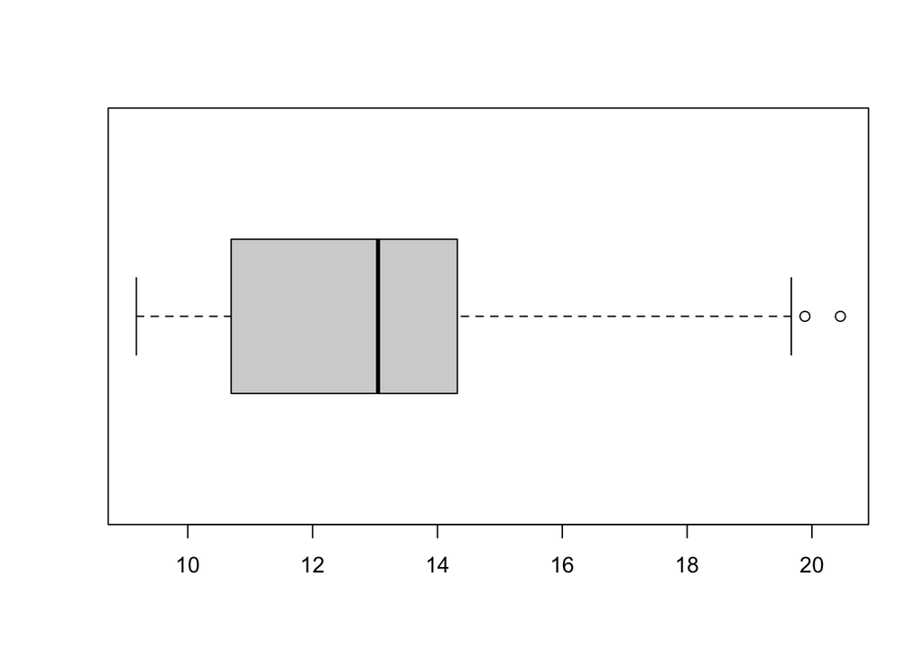

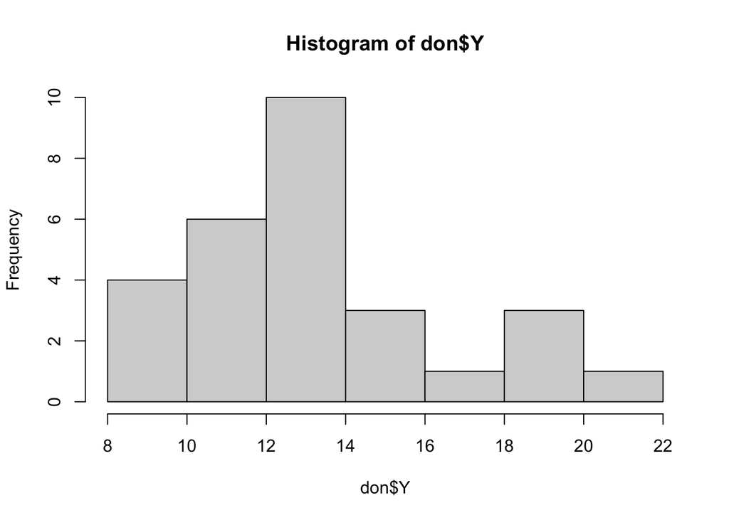

- **Commentaire** : Les résultats de la liste montrent une moyenne de **13.49%**, reflètant la performance moyenne obtenue. La médiane, légèrement inférieure, **13.05%**, indique que la moitié des résultats sont en dessous de cette valeur. Cette proximité entre la moyenne et la médiane suggère une homogénéité.

L’étendue,qui va de **9.17%** à **20.45%**, met en évidence une variation importante dans les résultats.

On voit grâce à l’histrogramme une distribution assez asymétrique.

Ce graphique permet également de montrer que la distribution est **unimodale**, avec un seul pic dominant autour de la moyenne.

L’écart-type est de **3,27**.

## B. HYPOTHESE GEOGRAPHIQUE : L’EFFET URBAIN-RURAL (4 pts)

> Dans cette partie vous devez analyser l’hypothèse d’une relation entre la situation urbaine ou rural des circonscriptions et les résultats de votre liste

### B.1 Résultats par type d’espace

> Votre liste obtient-elle de meilleurs résultats en milieu urbain ou rural ?

```
## # A tibble: 2 × 2
##   typo   moyenne_Y
##   <fct>      <dbl>
## 1 rural       11.4
## 2 urbain      15.9
```

**Commentaire** : on observe que la liste Glucksman obtient de meilleurs résultats en milieu urbain. Cela confirme les observations lors de l’introduction.

### B.2 Graphique

> Illustration de votre analyse

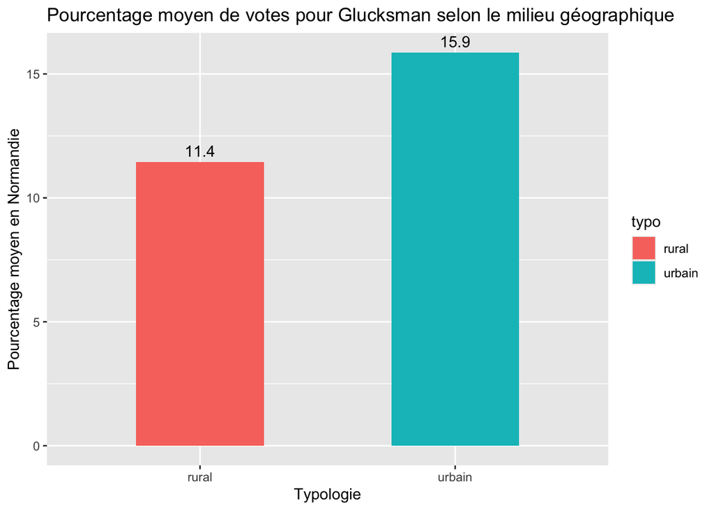

### B.3 Modélisation

> Les différences observées sont-elles significatives ?

```
##
##  Shapiro-Wilk normality test
##
## data:  don$Y
## W = 0.89962, p-value = 0.01121
```

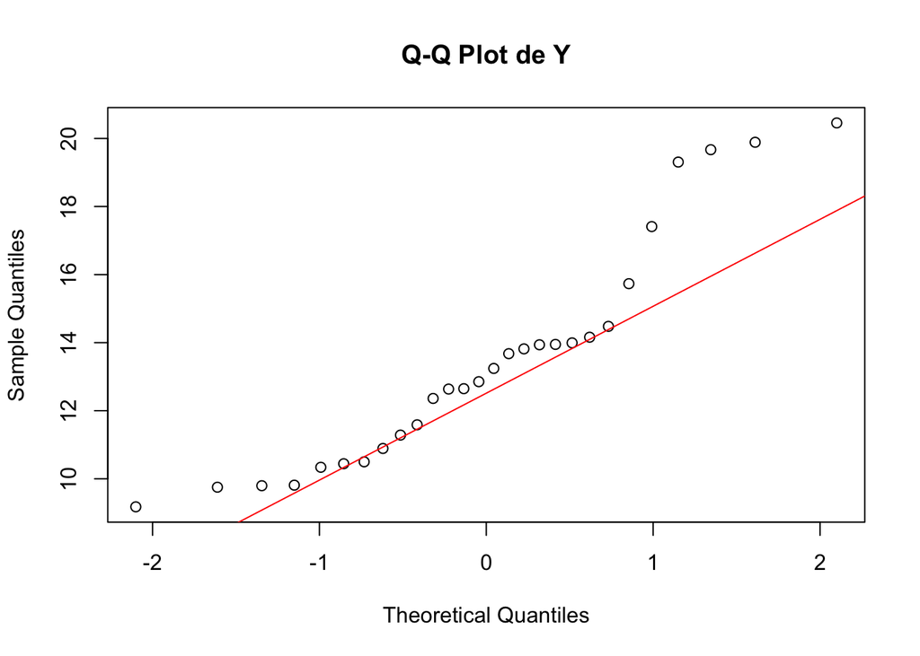

La p-value est inférieure à 0.05, ce qui signifie que l’hypothèse d’une distribution normale pour Y est rejetée. Les résultats ne suivent pas une distribution normale. Cela implique que les tests statistiques qui supposent une normalité (comme le test de Student) ne sont pas appropriés.

De plus, le QQ plot montre que les points s’écartent significativement de la ligne rouge, confirmant que les données ne suivent pas une distribution normale.

La distribution ne respecte pas les hypothèses classiques donc on utilise le teste de Wilcoxon.

```
##
##  Wilcoxon rank sum exact test
##
## data:  Y by typo
## W = 18, p-value = 8.354e-05
## alternative hypothesis: true location shift is not equal to 0
```

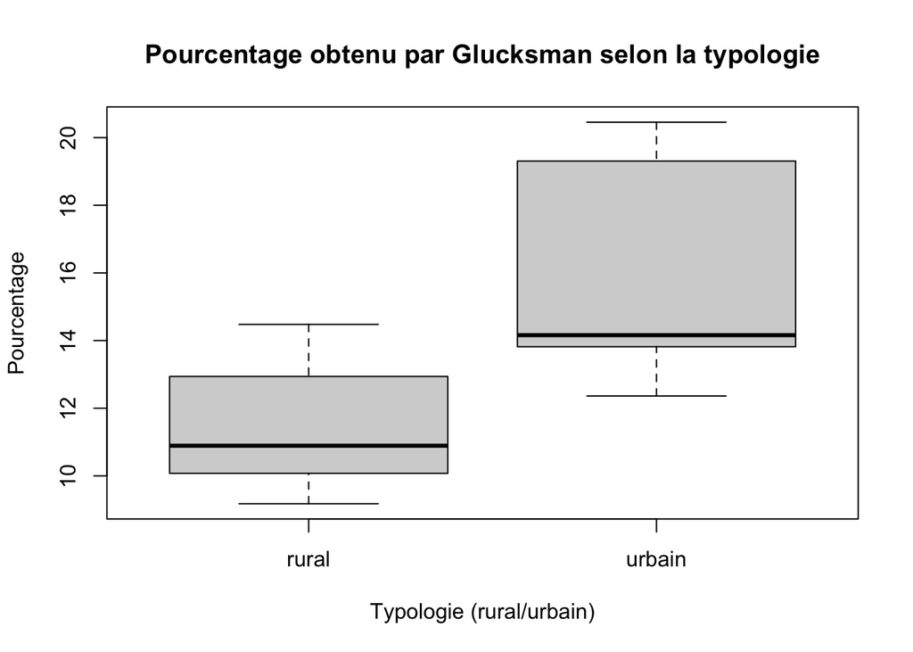

La p-value du test de Wilcoxon est largement inférieure à 0.01 ce qui indique une différence significative

### B.4 : Conclusion ?

> Que vous apprennent ces résultats en termes de prédiction ? en termes d’explication ?

Les résultats du test de Wilcoxon montrent une différence significative entre les deux groupes. Cela indique que la typologie des zones (rural/urbain) **influence** les performances de la liste Glucksmann de manière **significative**.

Les tests montrent également que les zones rurales et urbaines diffèrent significativement en termes de résultats pour la liste Glucksmann. Cela peut être expliqué par des circonstances sociales, économiques et politiques dans ces zones.

La typologie seule n’explique qu’une partie de la variation dans les résultats. Il est probable que d’autres variables doivent être intégrées pour affiner les prédictions.

Regardons à présent l’effet des CSP.

## C. HYPOTHESE SOCIO-ECONOMIQUE : L’EFFET DES CSP (4 pts)

> Dans cette partie vous devez analyser l’hypothèse d’une relation entre les catégories d’actifs présentes dans les circonscriptions et les résultats de votre liste.

### C.1 Choix de la CSP (X)

> Avec quel variable X observez vous la corrélation **la plus forte** ?

```
##               [,1]
## act_agr -0.3506634
## act_art -0.4321705
## act_cad  0.6459779
## act_emp  0.0702855
## act_int  0.5818125
## act_ouv -0.7502521
## act_cho  0.3618237
```

On observe que la corrélation la plus forte est avec les ouvriers. C’est une corrélation négative mais très forte avec un coefficient de -0.75.

Nous allons donc poursuivre cette analyse sur l’effet des actifs ouvriers sur les résultats.

### C.2 Visualisation de la relation

> Analysez la forme de la relation entre X et Y

#####Diagramme :

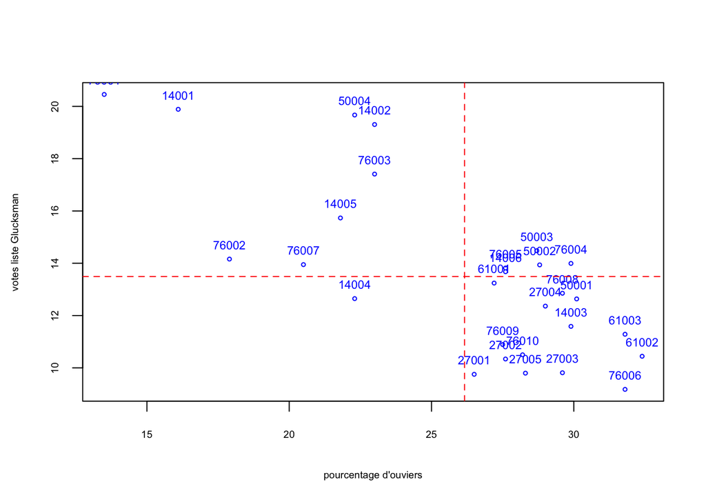

Sur ce diagramme, on observe que plus il y a d’ouvriers, moins il y a de vote pour la liste Glucksman. Et la majorité des circonscriptions se concentre en bas à droite ce qui le confirme.

#####Pearson et Spearman :

```
## [1] -0.7502521
```

```
## [1] -0.6148792
```

Les coefficient de pearson et de spearman sont tous les deux négatifs ce qui est une bonne chose. Ils sont relativement proches mais différents. Regardons si un autre modèle est plus adapté :

```
## [1] -0.7502521
```

```
## [1] -0.7296045
```

```
## [1] -0.7462466
```

```
## [1] -0.7204751
```

On peut continuer d’utiliser le modèle linéaire.

Donc, relation linéaire négative plutot forte. Vérifions si elle est significative :

```
##
##  Pearson's product-moment correlation
##
## data:  don$act_ouv and don$Y
## t = -5.7862, df = 26, p-value = 4.281e-06
## alternative hypothesis: true correlation is not equal to 0
## 95 percent confidence interval:
##  -0.8776682 -0.5237829
## sample estimates:
##        cor
## -0.7502521
```

La relation est très **significative** (pvalue<0.01).

Pour conclure la représentation de la relation entre X et Y, la relation est **linéaire** (coefficient de pearson et de spearman sont proches) et **négative** plutot forte. De plus, la relation est très **significative** (p-value < 0.01).

```
##
##  Shapiro-Wilk normality test
##
## data:  don$act_ouv
## W = 0.88818, p-value = 0.006117
```

La distribution ne suit pas une loi normale.

### C.3 Modélisation de la relation

> Modélisez la relation entre X et Y

##### Régression linéaire

```
##
## Call:
## lm(formula = don$Y ~ don$act_ouv)
##
## Residuals:
##     Min      1Q  Median      3Q     Max
## -3.5683 -1.9467  0.2892  1.1785  4.2252
##
## Coefficients:
##             Estimate Std. Error t value Pr(>|t|)
## (Intercept) 26.71773    2.32347  11.499 1.07e-11 ***
## don$act_ouv -0.50553    0.08737  -5.786 4.28e-06 ***
## ---
## Signif. codes:  0 '***' 0.001 '**' 0.01 '*' 0.05 '.' 0.1 ' ' 1
##
## Residual standard error: 2.21 on 26 degrees of freedom
## Multiple R-squared:  0.5629, Adjusted R-squared:  0.5461
## F-statistic: 33.48 on 1 and 26 DF,  p-value: 4.281e-06
```

Lorsque la proportion d’ouvriers est nulle, le modèle prédit un résultat de 26.71 % pour la liste de Glucksman. De plus, pour chaque augmentation de 1% de la proportion d’ouvriers, il y aura une baisse moyenne de 0.505 points dans le pourcentage.

Cela nous donne la droite de régression :

**Y = -0.505*X + 26.71**

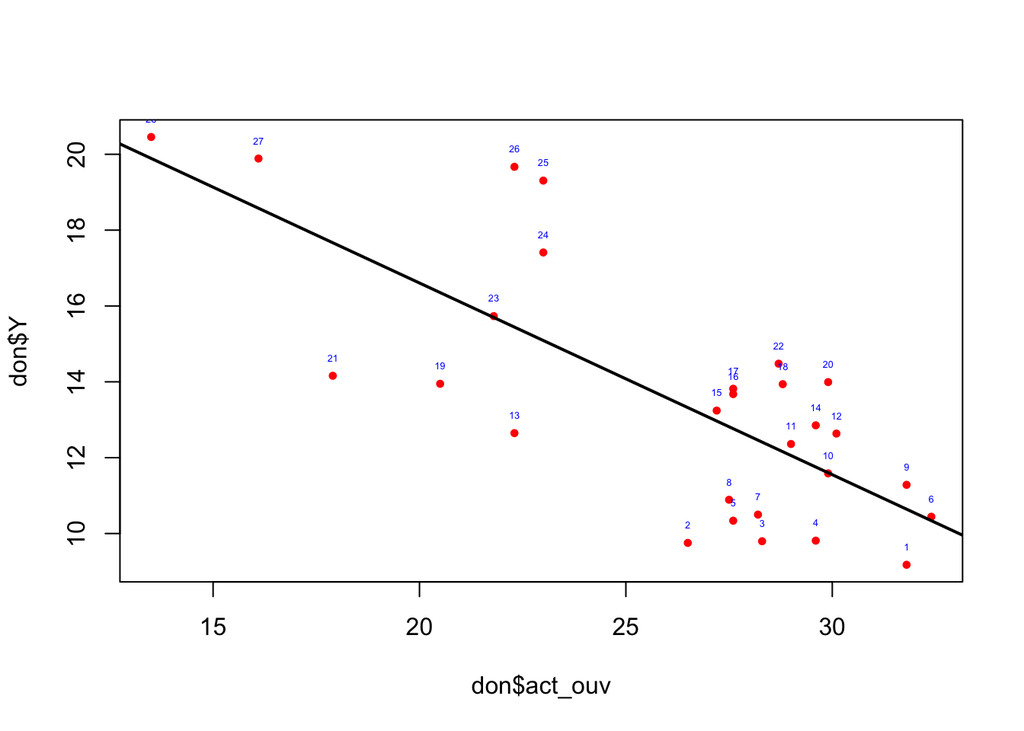

```
##      circ           dept      regi   typo     Aubry Bardella   Bellamy
## 341 76006 SEINE-MARITIME NORMANDIE  rural  3.784917 44.91790  6.560523
## 464 27001           EURE NORMANDIE  rural  6.611692 42.34904  6.227700
## 95  27005           EURE NORMANDIE  rural  6.979608 42.75469  6.569170
## 93  27003           EURE NORMANDIE  rural  4.345958 44.42654  6.287403
## 465 27002           EURE NORMANDIE  rural  6.349729 42.56110  6.125434
## 254 61002           ORNE NORMANDIE  rural  4.524742 39.09737  9.180090
## 343 76010 SEINE-MARITIME NORMANDIE  rural  4.050578 43.63872  7.510413
## 342 76009 SEINE-MARITIME NORMANDIE  rural  4.570479 42.84599  6.057937
## 255 61003           ORNE NORMANDIE  rural  5.536270 36.23263 10.049098
## 54  14003       CALVADOS NORMANDIE  rural  5.306661 38.76464  6.878691
## 94  27004           EURE NORMANDIE urbain  8.194738 41.10211  5.486155
## 211 50001         MANCHE NORMANDIE  rural  4.596789 33.59812  8.264277
## 55  14004       CALVADOS NORMANDIE urbain  4.515869 32.38478  8.673836
## 438 76008 SEINE-MARITIME NORMANDIE urbain 13.242860 31.43043  4.582358
```

[output cut: 101 more lines]

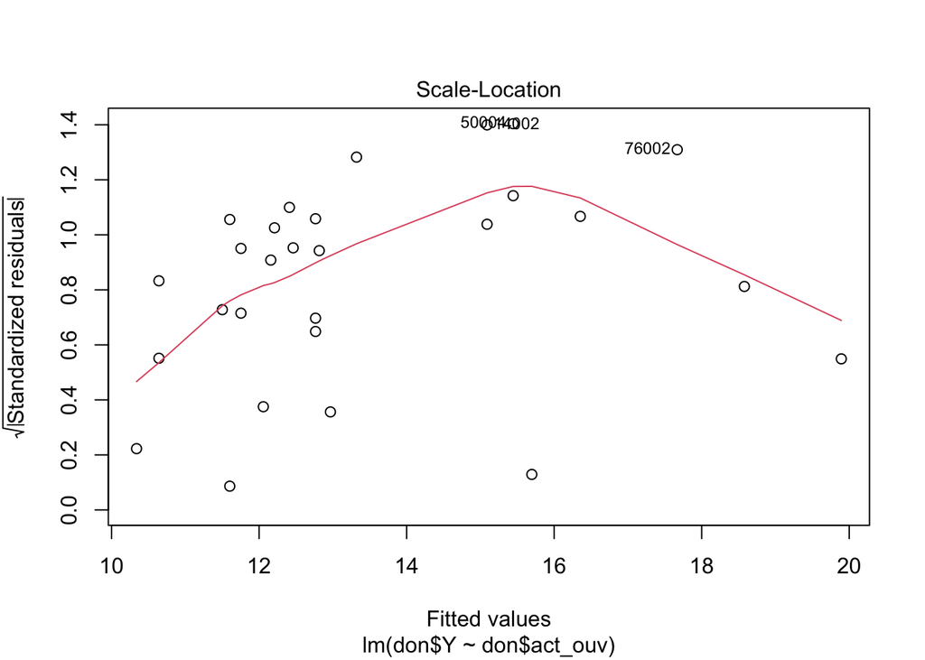

```
## Non-constant Variance Score Test
## Variance formula: ~ fitted.values
## Chisquare = 1.600454, Df = 1, p = 0.20584
```

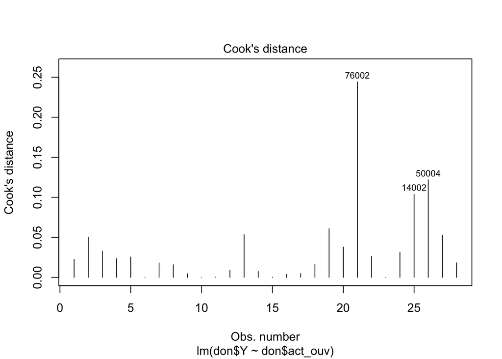

```
## No Studentized residuals with Bonferroni p < 0.05
## Largest |rstudent|:
##       rstudent unadjusted p-value Bonferroni p
## 50004 2.095773            0.04639           NA
```

### C.4 Discussion des résultats

> Que vous apprennent ces résultats en termes de prédiction ? en termes d’explication ?

La relation entre le nombre d’ouvriers présents dans la circonscription est négative et forte. Ce qui signifie que la présence d’ouvrier dans la zone de vote influence effectivement le résultat. Plus il y a d’ouvriers, moins il y a de vote pour la liste Glucksman en Normandie.

Cependant, le R^2 modéré et la dispersion des résidus montre qu’il y a d’autres facteurs qui pourraient influencer le résultat.

Il y a quand même certaines circonscriptions avec de grandes différences entre le Y estimé du modèle et le Y observé (Y étant le resultat de la liste Glucksmann). Cela montre que la présence d’ouvriers n’explique pas à elle seule les résultats.

## D. PARTIE LIBRE (4 pts)

> Poursuivez l’analyse. Vous pouvez par exemple : - étudier l’effet d’autres variables comme le niveau d’étude ? le département ? - refaire vos analyses pour un parti ami ? pour un parti rival ? - refaire vos analyse dans une autre région ? pour la France entière ? - essayer de combiner les variables géographiques et socio-économiques ? - etc.

Notre principal concurrent étant la liste Bardella et les ouvriers étant ceux qui votent le moins pour la liste Glucksman… Existe-t-il une relation entre la présente d’ouvrier et la réussite de la liste Bardella ?

###D.1 Corrélation

Regardons s’il existe une corrélation entre la liste Bardella et les ouvriers.

```
##                [,1]
## act_agr  0.21613217
## act_art  0.26360675
## act_cad -0.63323107
## act_emp -0.09907504
## act_int -0.37260996
## act_ouv  0.74474118
## act_cho -0.40214484
```

On remarque que la corrélation la plus forte entre la liste Bardella et les CSP en Normandie est avec les actifs ouvriers. C’est une relation **positive** forte avec **0.74** soit l’exact opposé que pour la liste Glucksman…

### D.2 Visualisation de la relation

> Analysez la forme de la relation entre X et Y

#####Diagramme :

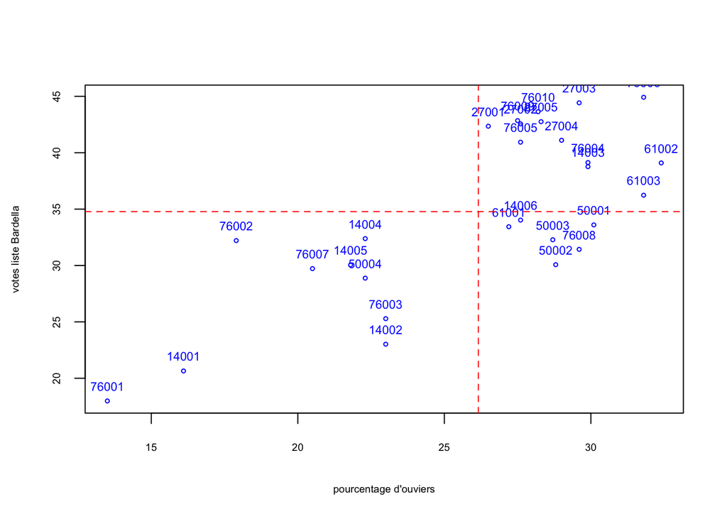

La représentation forme bien le contraire que pour la liste de Glucksman. Plus il y a d’ouvriers dans la circonscription, plus il y a de vote pour Bardella.

#####Pearson et Spearman :

```
## [1] 0.7447412
```

```
## [1] 0.5951505
```

Les coefficient de pearson et de spearman sont tous les deux positif ce qui est une bonne chose. Ils sont très différents. Regardons si un autre modèle est plus adapté :

```
## [1] 0.7447412
```

```
## [1] 0.775777
```

```
## [1] 0.7500184
```

```
## [1] 0.7899863
```

C’est le modèle linéaire qui reste le plus proche du coefficient de spearman.

### D.3

Régression linéaire :

```
##
## Call:
## lm(formula = don$Bardella ~ don$act_ouv)
##
## Residuals:
##     Min      1Q  Median      3Q     Max
## -8.1504 -3.3477 -0.1003  4.7687  7.1844
##
## Coefficients:
##             Estimate Std. Error t value Pr(>|t|)
## (Intercept)   4.9121     5.3353   0.921    0.366
## don$act_ouv   1.1416     0.2006   5.690 5.49e-06 ***
## ---
## Signif. codes:  0 '***' 0.001 '**' 0.01 '*' 0.05 '.' 0.1 ' ' 1
##
## Residual standard error: 5.074 on 26 degrees of freedom
## Multiple R-squared:  0.5546, Adjusted R-squared:  0.5375
## F-statistic: 32.38 on 1 and 26 DF,  p-value: 5.493e-06
```

Lorsque la proportion d’ouvriers est nulle, le modèle prédit un résultat de 4.91 % pour la liste de Bardella, ce qui est très faible.  
De plus, pour chaque augmentation de 1% de la proportion d’ouvriers, il y aura une augmentation moyenne de 1.1 points dans le pourcentage.

Les ouvriers jouent un rôle très significatif dans la popularité de la liste Bardella.

## CONCLUSION (2 pts)

Les résultats montrent que la liste Glucksmann a obtenu en moyenne **13.49%** des votes en Normandie, avec une médiane légèrement inférieure (13.05%), reflétant une distribution relativement homogène mais présentant une certaine asymétrie. L’étendue des résultats, allant de 9.17 % à 20.45 %, met en évidence des **variations importantes** entre les circonscriptions. L’écart-type de 3.27 % confirme une dispersion modérée des résultats.

La typologie des zones (rural/urbain) joue un rôle **significatif** dans les résultats, comme le montrent les tests statistiques. Les zones rurales enregistrent globalement des scores plus faibles pour la liste Glucksmann, tandis que les **zones urbaines** lui sont plus **favorables**. Cette différence reflète des différences sociologiques, économiques et politiques propres à chaque type de territoire.

La proportion d’ouvriers dans les circonscriptions présente une corrélation négative et forte avec les résultats de la liste confirmant que plus la présence ouvrière est importante, moins la liste Glucksmann est performante. Cependant, le modèle de régression linéaire montre des limites avec un R^2 indiquant que d’autres facteurs, comme le niveau de diplôme ou le taux de chômage, influencent également les résultats. Les résidus élevés pour certaines circonscriptions confirment que la seule variable “proportion d’ouvriers” ne suffit pas à expliquer l’ensemble des variations.

Les perspectives de recherches futures pourraient être d’intégrer d’autres variables explicatives à ce modèle, comme par exemple le niveau de diplome, le taux de chomage, les tensions urbaines…

Mon conseil pour les militants de Normandie, c’est de cibler les zones rurales. Les résultats montrent une sous-performance importante dans les zones rurales, particulièrement celles avec une forte présence ouvrière. Les militants devraient concentrer leurs efforts sur ces territoires.

Il faut également renforcer la communication auprès des ouvriers, qui ne sont pas motivés pour voter la liste Glucksmann.

> Indiquez les perspectives de recherches futures.